# Tài liệu chọn lọc

**Biên soạn**

Duc Nguyen | [www.tuhocr.com](https://www.tuhocr.com/)

**Cập nhật**

2024 October 31

[Register](https://www.tuhocr.com/register) [Web](https://www.tuhocr.com/) [BibTeX](https://applyr.netlify.app/codebase/growing/growing.txt)

# 1 Probability and statistics

Giáo trình xác suất thống kê

[figure not shown]

Probability and Statistics for Engineering and the Sciences. 8th edition. Jay L. Devore (Devore 2011)[^1]

Tài liệu này được recommend[^2]

[`Probability and Statistics with R, 2nd edition. Ugarte, Militino, and Arnholt`](https://longliveturtle.github.io/water/p6.pdf)

# 2 Linear regression

Cách giải thích kết quả hồi quy tuyến tính đơn biến

[`Simple linear regression. Slide from https://www.colorado.edu/amath`](https://longliveturtle.github.io/water/p2.pdf)

[`Linear models. Slide from https://amath.colorado.edu/faculty/vdukic/4570/`](https://longliveturtle.github.io/water/p3.pdf)

# 3 Logistic regression

Cách vẽ đường cong ROC (Receiver Operating Characteristics)

[`Fawcett, T. (2006). An introduction to ROC analysis. Pattern Recognition Letters, 27(8), 861–874.`](https://longliveturtle.github.io/water/p1.pdf)

[`Bài giảng 35 (Dịch tễ học): Cách vẽ đường cong ROC với R`](https://longliveturtle.github.io/water/p14.mp4) | [youtube](https://youtu.be/Ugnebc0rYHo?si=jm6urto5YysB-uY9)

https://www.medcalc.org/manual/roc-curves.php

# 4 Time series in R

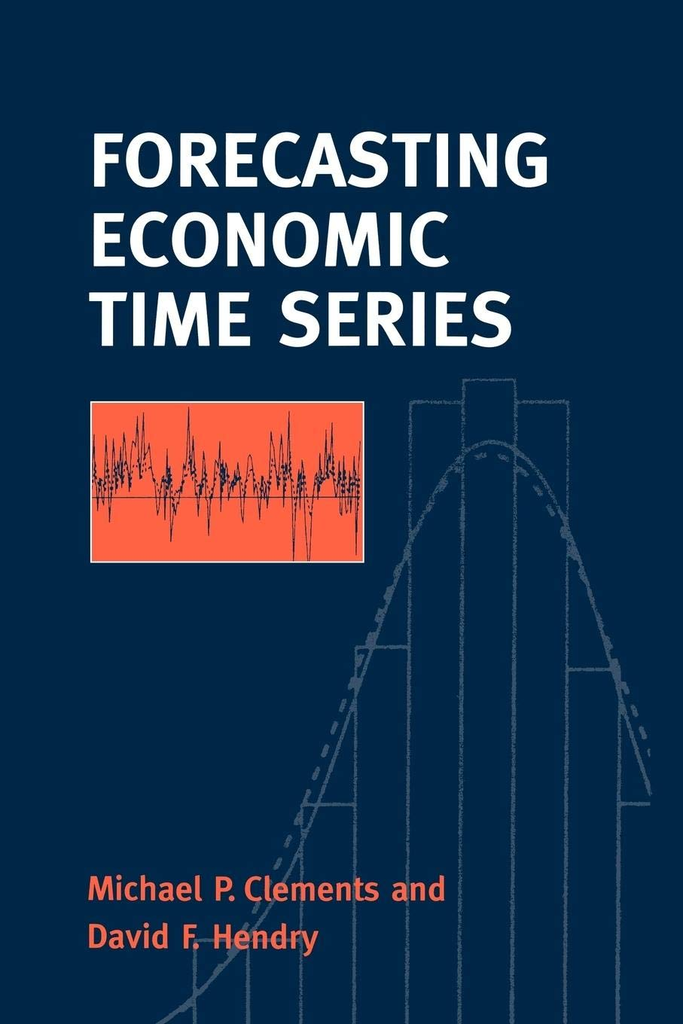

Forecasting economic time series (Clements and Hendry 1998)

# 5 Poisson regression

Model GPL<sub>Poisson</sub> ước tính tỷ lệ tử vong của cá theo độ tuổi

[`Mainguy, J., & De Andrade Moral, R. (2021). An Improved Method for the Estimation and Comparison of Mortality Rates in Fish from Catch‐Curve Data. North American Journal of Fisheries Management, 41(5), 1436–1453.`](https://longliveturtle.github.io/water/p13.pdf)

# 6 Biology

Khái niệm recruitment (biology)[^3]

# 7 Economics

[figure not shown]

Marketing analytics sử dụng Excel (Winston 2014)

[figure not shown]

Business analytics sử dụng Excel (Evans 2017)

# 8 SEM

`Sleep quality mediating the association of personality traits and quality of life among underground workers and surface workers of Chinese coal mine: A multi-group SEM with latent response variable mediation analysis`

`Mediator of school belongingness and moderator of migration status in the relationship between peer victimization and depression among Chinese children: A multi-group structural equation modeling approach`

# 9 Ước tính trữ lượng thủy sản

Estimating total mortality rates

[`Huynh, Q. C., Gedamke, T., Porch, C. E., Hoenig, J. M., Walter, J. F., Bryan, M., & Brodziak, J. (2017). Estimating Total Mortality Rates from Mean Lengths and Catch Rates in Nonequilibrium Situations. Transactions of the American Fisheries Society, 146(4), 803–815.`](https://longliveturtle.github.io/water/p11.pdf)

Ước tính trữ lượng thủy sản dựa vào chiều dài cá

[`Length-based integrated mixed effects model`](https://github.com/merrillrudd/LIME) | LIME

Mean length-based mortality estimators (MLZ)[^4]

# 10 R in HPC

[`Managing R on HPC systems`](https://hackmd.io/@bbolker/r_hpc)

[`Exploiting parallelism in R`](https://docs.alliancecan.ca/wiki/R#Exploiting_parallelism_in_R)

# 11 Deep learning

[`Deep learning in R`](https://www.r-tutor.com/deep-learning/introduction)

# 12 R programming

## 12.1 Data visualization

Vẽ đồ thị cho biến phân loại sử dụng R (Friendly and Meyer 2016)

## 12.2 R coding

[`Using R for Data Analysis and Graphics from https://cran.r-project.org/doc/contrib/`](https://longliveturtle.github.io/water/p5.pdf)

[`Hướng dẫn sử dụng R của trường UCLA`](https://stats.oarc.ucla.edu/r/)

[`R in Action https://www.manning.com/books/r-in-action`](https://longliveturtle.github.io/water/p8.pdf)[^5] | [`3th edition`](https://longliveturtle.github.io/water/p9.pdf)

[`R Tutorial https://www.r-tutor.com/`](https://www.r-tutor.com/elementary-statistics)

[`simpleR - Using R for Introductory Statistics`](https://longliveturtle.github.io/water/p10.pdf)

# 13 Reproducible report

Format Quarto[^6]

# 14 Bash programming

Các lệnh Bash script (Parker 2011)

# 15 Dataset

Trang này được recommend[^7]

[Dataset minh họa các bài tập thống kê](http://www.statsci.org/datasets.html) | https://web.archive.org/

**Các kỹ thuật tin học thường dùng**

Đây là các công cụ mình áp dụng trên máy tính, các bạn tham khảo nhé. Thanks.

# 16 Citation tool

Tự động tạo citation

[`https://quillbot.com/citation-generator/`](https://quillbot.com/citation-generator/)

# 17 Download tool

Tải video youtube. Cách sử dụng[^9]: mở `cmd` trên windows sau đó gõ `yt-dlp url`

[`https://github.com/yt-dlp/yt-dlp`](https://github.com/yt-dlp/yt-dlp)

# 18 Password protected

Để tạo file HTML có password, ta cài đặt [`Node.js`](https://nodejs.org/en/learn/getting-started/an-introduction-to-the-npm-package-manager) khi đó có gói package `npm` dùng để install tiếp package [`staticrypt`](https://www.npmjs.com/package/staticrypt).

# 19 Other tools

Để backup file giữa các ổ đĩa, sử dụng FreeFileSync[^10]. Sử dụng KeePass[^11] để lưu mật khẩu.

# 20 Kiến trúc HTML

1. https://hocwebchuan.com/reference/cssSection/pr_vertical-align.php
2. Tạo callout (note ghi chú) trong Quarto https://quarto.org/docs/authoring/callouts.html

# 21 Free software GNU

1. https://libreplanet.org/wiki/Main_Page
2. https://www.fsf.org/
3. https://www.gnu.org/

# 22 Nguồn

Clements, Michael P., and David F. Hendry. 1998. *Forecasting Economic Time Series*. CRC Press. https://longliveturtle.github.io/water/p7.pdf.

Devore, Jay L. 2011. *Probability and Statistics*. 8th ed. Cengage Learning. https://longliveturtle.github.io/water/p4.pdf.

Evans, James. 2017. *Business Analytics*. 2nd ed. Pearson. https://longliveturtle.github.io/water/p17.pdf.

Friendly, Michael, and David Meyer. 2016. *Discrete Data Analysis with R*. CRC Press. https://t.me/self_sustaining_system/3.

Parker, Steve. 2011. *Shell Scripting*. https://longliveturtle.github.io/water/p15.pdf.

Winston, Wayne L. 2014. *Marketing Analytics*. Wiley. https://longliveturtle.github.io/water/p16.pdf.

## Footnotes

[^1]: http://drhuang.com/science/mathematics/book/
[^2]: https://amath.colorado.edu/faculty/vdukic/4570/
[^3]: https://en.wikipedia.org/wiki/Recruitment_(biology)
[^4]: https://git.csic.es/math4fish/ieoinputsa_ss3/-/blob/e4b3c488128136a9599175baf7c777409d65ed91/modelos_datapoor/entregable_1_4-main/RefPts/MLZ/Previous%20runs/Final%20html%20(both%20models)/mlz.Rmd  
    **Tham khảo:**  
    Gedamke, T. and Hoenig, J.M. (2006), Estimating Mortality from Mean Length Data in Nonequilibrium Situations, with Application to the Assessment of Goosefish. Transactions of the American Fisheries Society, 135: 476-487.  
    Then, AY; Hoenig, JM; and Huynh, QC, Estimating fishing and natural mortality rates, and catchability coefficient, from a series of observations on mean length and fishing effort (2018). Ices Journal Of Marine Science, 75(2), 610-620.
[^5]: File data https://longliveturtle.github.io/water/p8.zip
[^6]: https://smithcollege-sds.github.io/sds100/lab_08_formatting.html
[^7]: https://amath.colorado.edu/faculty/vdukic/4570/4570resources.html
[^8]: https://www.recoll.org/
[^9]: https://blogchiasekienthuc.com/thu-thuat-internet/cach-su-dung-yt-dlp-de-tai-video.html
[^10]: https://freefilesync.org/
[^11]: https://keepass.info/